# BMIN503/EPID600 Project

Zheyuan(Aria) Huang

### Overview

The project aims to design protein circuits that can sense diseased protein aggregates in cancer cells and in turn activate an apoptosis pathway to cause targeted cell death. The data analyzed here are collected based on cell survival count after cells transfected with different apoptotic constructs being stimulated with blue light at various time points. The goal of this project is to determine the optimal protein circuit design that achieve the maximum targeted apoptosis in host cells.

### Introduction

The goal of the project is to engineer protein circuit that could lead to controlled apoptosis thus creating a therapeutic tool for cancer treatment. Traditional cancer therapies are highly invasive and cause damage to a lot of benign cells. By using a targeted protein circuit, the cancer cells that express certain protein aggregates can be detected via the binding domain of the circuit, thus activating the cleavage of the apoptosis subunit to be released into the cytoplasm. This approach demonstrates significant advancement from current practices such as chemotherapy in directly target cancer cells and killing those population. The problem of interest here seeks the expertise from protein engineering, cell signaling, cancer biology, and quantitative analysis. By combining knowledge from these fields, we will be able to deepen our knowledge on protein clustering as an emergent form of cancer therapy.  
From my conversations with the faculties, I realized that the dataset might seem simple from a mathematical perspective, but to interpret it correctly and drawing the correlation between different techniques with phenotype will be challenging. It will be crucial to put any finding into the context and evaluate the results by biological and technical principles.

### Methods

The data that I plan to analyze here are collected by a former graduate student from the Bugaj lab at Bioengineering. The experiment utilized an optogenetic tool to validate the protein circuit they designed. Upon blue light stimulation, the GFP in the cells cluster together therefore activate the downstream death circuit. All the data were collected from confocal microscopy images which were pre-analyzed using imageJ. Raw cell counts and the time points were recorded in the two source files, expression over time.csv and death expression.csv. Using the time point fluorescence data collected on cells transfected with different constructs, I plan to analyze: 1. fluorescence progression throughout the time course  
2. cell count for fluorescence expressing cells and dying cells at each time point 3. expression difference between stimulated and basal cells

### Time point data

```r
install.packages("reshape",repos = "http://cran.us.r-project.org")
install.packages("ggthemes",,repos = "http://cran.us.r-project.org")
```

```r
library(ggplot2)
library(reshape)
library(ggthemes)
# read in time point data
tpdata <- read.csv(
  file = "expression over time.csv",
  header = TRUE,
  sep = ",",
  dec = "."
)
head(tpdata)
```

```
##   time mch.Split mch.S mch.Q mch.L mch.M mch.Cry2 mch.f.Split mch.f.S mch.f.Q mch.f.L mch.f.M mch.f.Cry2 mch.d.Split mch.d.S mch.d.Q mch.d.L mch.d.M mch.d.Cry2 mch.f.d.Split mch.f.d.S mch.f.d.Q mch.f.d.L mch.f.d.M mch.f.d.Cry2
## 1    0       115    78   106   247   120      402          37      42      42      57      34        402          31      24      21      36      23         35             9        24        10        11        11           35
## 2    2       140   122   154   323   130      514          53      42      68      76      43        514          51      37      30      22      35         16            29        23        19        13        14           16
## 3    6       259   202   262   573   250      863          86      73     110     135      88        863         143      91      72      51     102         50            58        57        23        24        45           50
## 4    8       405   298   378   761   395      924         118     123     160     170     138        924         206     145     104      75     161         59            81        91        46        25        66           59
## 5   12       527   433   538  1005   513     1152         168     151     181     193     190       1152         291     237     146     101     246         78           134       116        72        44        97           78
```

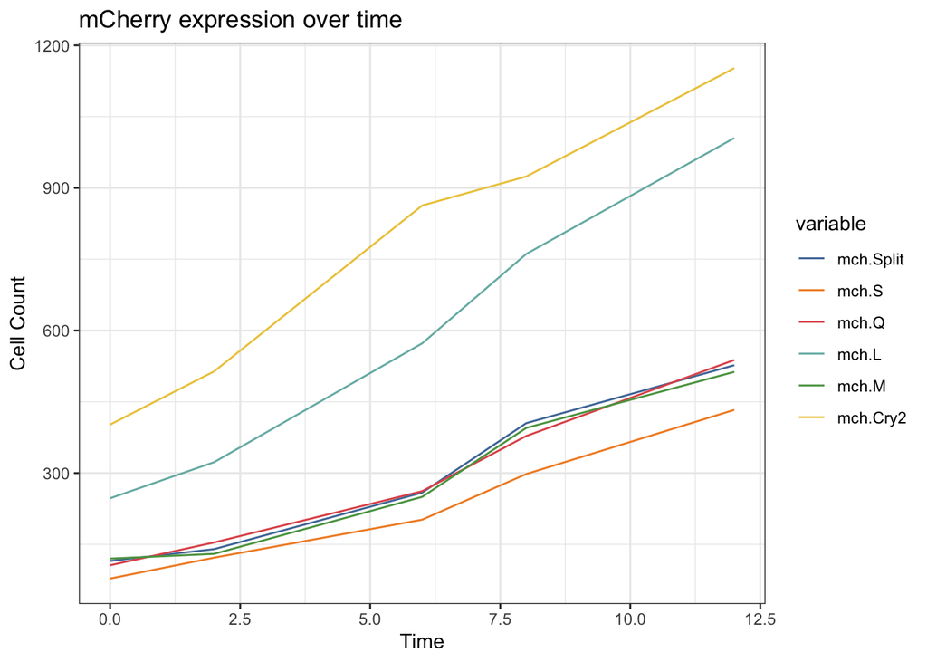

```r
# subset data to create groups
mchdata <- tpdata[c(1:7)]
mchfdata <- tpdata[c(1,8:13)]
mchddata <- tpdata[c(1,14:19)]
mchfddata <- tpdata[c(1,20:25)]


# melt data so that multiple lines can be plotted together
mchdata.m <-melt(mchdata,id.vars="time")
mchfdata.m <-melt(mchfdata,id.vars="time")
mchddata.m <-melt(mchddata,id.vars="time")
mchfddata.m <-melt(mchfddata,id.vars="time")


# plot time point data
ggplot(mchdata.m, aes(x=time, y=value, colour=variable)) +
    geom_line() +
    theme_bw()+scale_colour_tableau()+
    labs(x="Time", y="Cell Count", title='mCherry expression over time')
```

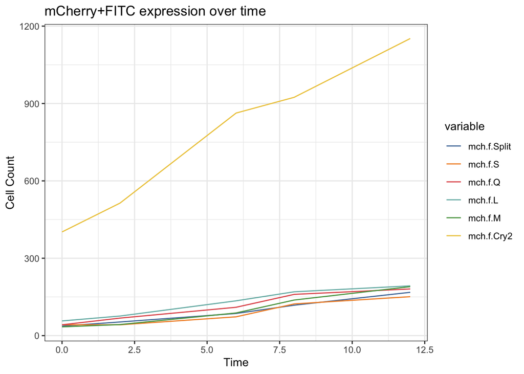

```r
ggplot(mchfdata.m, aes(x=time, y=value, colour=variable)) +
    geom_line() +
    theme_bw()+scale_colour_tableau()+
  labs(x="Time", y="Cell Count", title='mCherry+FITC expression over time')
```

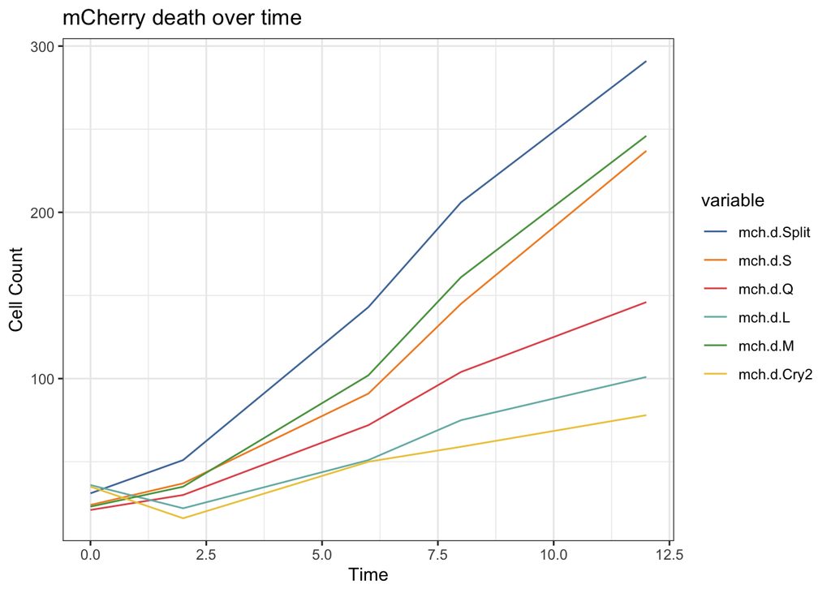

```r
ggplot(mchddata.m, aes(x=time, y=value, colour=variable)) +
    geom_line() +
    theme_bw()+scale_colour_tableau()+
  labs(x="Time", y="Cell Count", title='mCherry death over time')
```

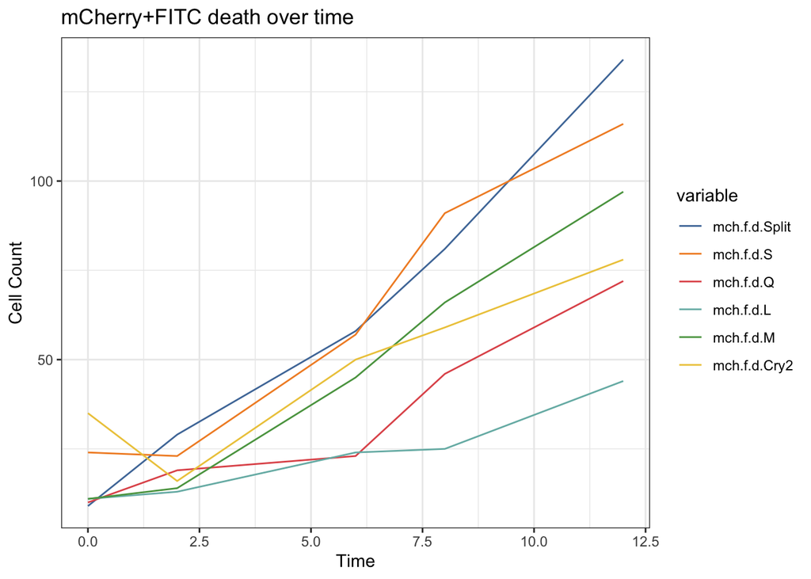

```r
ggplot(mchfddata.m, aes(x=time, y=value, colour=variable)) +
    geom_line() +
    theme_bw()+scale_colour_tableau()+
  labs(x="Time", y="Cell Count", title='mCherry+FITC death over time')
```

### Expression/death analysis

```r
# load death expression data
library(dplyr)
library(tidyr)
```

```r
library(ggplot2)
library(ggthemes)
dedata <- read.csv(
  file = "death expression.csv",
  header = TRUE,
  sep = ",",
  dec = "."
)
head(dedata)
```

```
##   time cond mCh FITC Dapi both Dapi.mCh Dapi.Fitc Dapi.Both
## 1    0    1 115   18   95   14       31        14        10
## 2    0    2  78   19   70   16       24        13        11
## 3    0    3 106   26   48   21       21        14         9
## 4    0    4 247   31   68   26       36        25        20
## 5    0    5 120   21   57   18       23        12         9
## 6    0    6  70  151   92   37       21        14         9
```

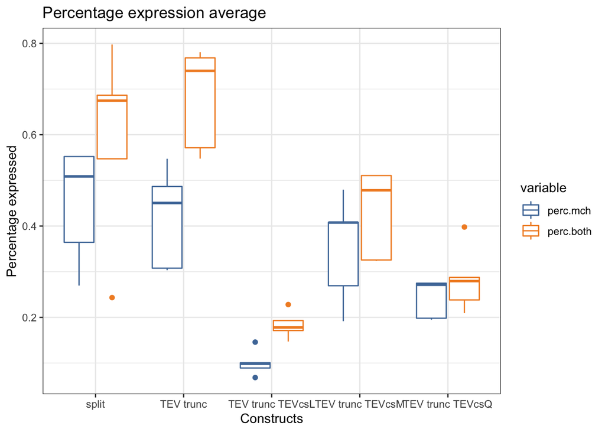

```r
# calculate the % dying/expressing cell by comparing the +DAPI groups with the no DAPI groups
dedata$perc.mch<-dedata$Dapi.mCh/dedata$mCh
dedata$perc.fitc<-dedata$Dapi.Fitc/dedata$FITC
dedata$perc.both<-dedata$Dapi.Both/dedata$both

# assign stimulated/unstimulated status based on plate setup
dedata$status[dedata$cond>5] <- 1
dedata$status[dedata$cond<6] <- 0
dedata$status[dedata$cond>10] <- "control"
dedata$status[dedata$cond==12]<-"cry2"

# filter by status
stim<-filter(dedata,status=="1")
base<-filter(dedata,status=="0")

# find difference between basal and stimulated (mcherry only and mcherry+fitc)
difstim<-data.frame(base$time,base$perc.mch,stim$perc.both)
difstim$delta<-difstim$stim.perc.both-difstim$base.perc.mch
names(difstim)[1:3] <- c('time',"perc.mch","perc.both")
difstim$construct<-rep(c("split","TEV trunc","TEV trunc TEVcsQ","TEV trunc TEVcsL","TEV trunc TEVcsM"),times=5)
# rename constructs
difstim.m <-melt(difstim,id.vars="construct")

# plot average percent expression for all the constructs
difstim.m<-melt(difstim, id = "construct", measure = c("perc.mch","perc.both"))
ggplot(difstim.m, aes(x=construct, y=value, colour=variable)) +
    geom_boxplot() +
    theme_bw()+scale_colour_tableau()+
    labs(x="Constructs", y="Percentage expressed",title='Percentage expression average')
```

```r
# paired t-test on the difference between unstimulated and stimulated groups
t.test(difstim$perc.both,difstim$perc.mch, paired = TRUE, alternative = "two.sided")
```

```
##
##  Paired t-test
##
## data:  difstim$perc.both and difstim$perc.mch
## t = 6.1304, df = 24, p-value = 2.475e-06
## alternative hypothesis: true difference in means is not equal to 0
## 95 percent confidence interval:
##  0.08014243 0.16149335
## sample estimates:
## mean of the differences
##               0.1208179
```

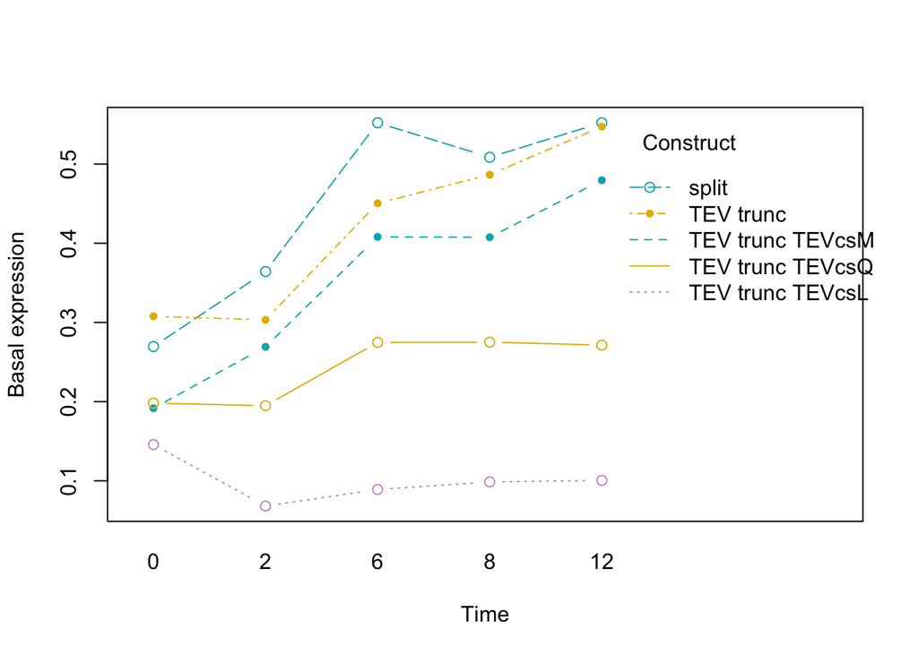

```r
# plot the basal expression
interaction.plot(x.factor = difstim$time, trace.factor = difstim$construct,
                 response = difstim$perc.mch, fun = mean,
                 xlab = "Time", ylab="Basal expression",
                 type = "b", legend = TRUE,
                 labs(fill='Construct'),
                 pch=c(1,20),col = c("#00AFBB", "#E7B800","#CC99CC"))
```

```r
# two-way anova on the interaction effects of constructs/time on basal expression
aov1 <- aov( perc.mch~ time + construct + time:construct, data = difstim)
summary(aov1)
```

```
##                Df Sum Sq Mean Sq F value   Pr(>F)
## time            1 0.1047 0.10467  65.292 7.61e-07 ***
## construct       4 0.4072 0.10179  63.493 3.20e-09 ***
## time:construct  4 0.0488 0.01219   7.605  0.00148 **
## Residuals      15 0.0240 0.00160
## ---
## Signif. codes:  0 '***' 0.001 '**' 0.01 '*' 0.05 '.' 0.1 ' ' 1
```

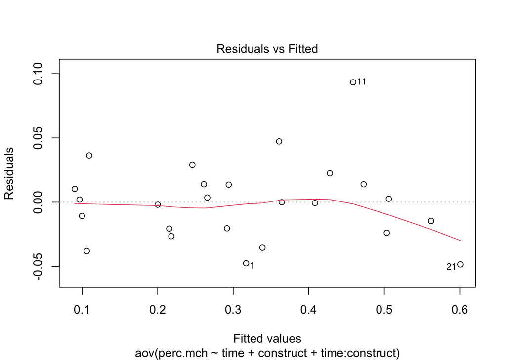

```r
# variance check
plot(aov1, 1)
```

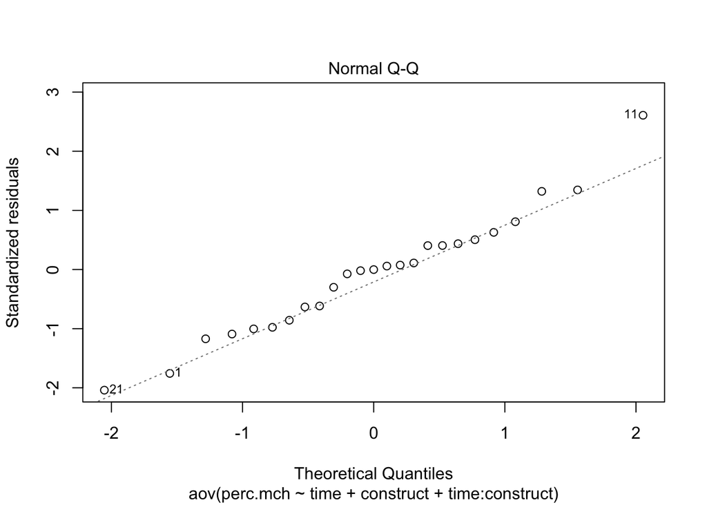

```r
# normality check
plot(aov1, 2)
```

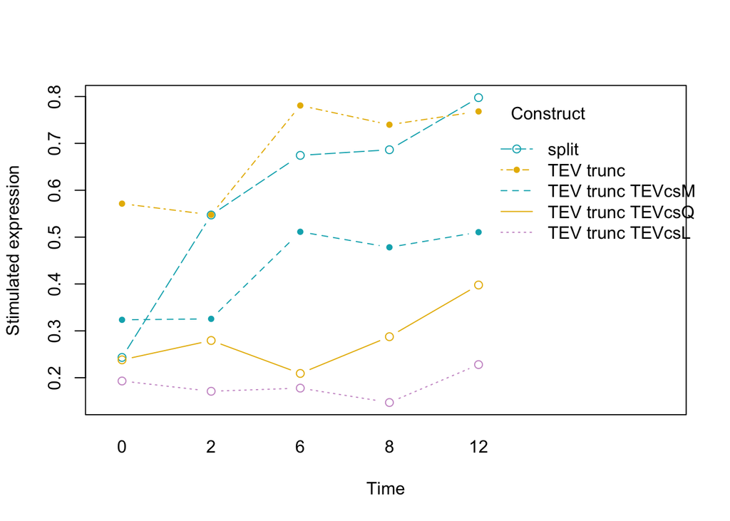

```r
# plot the stimulated expression
interaction.plot(x.factor = difstim$time, trace.factor = difstim$construct,
                 response = difstim$perc.both, fun = mean,
                 xlab = "Time", ylab="Stimulated expression",
                 type = "b", legend = TRUE,
                 labs(fill='Construct'),
                 pch=c(1,20),col = c("#00AFBB", "#E7B800","#CC99CC"))
```

```r
# two-way anova on the interaction effects of constructs/time on stimulated expression
aov2 <- aov( perc.both~ time + construct + time:construct, data = difstim)
summary(aov2)
```

```
##                Df Sum Sq Mean Sq F value   Pr(>F)
## time            1 0.1520 0.15202  33.547 3.55e-05 ***
## construct       4 0.8569 0.21423  47.276 2.50e-08 ***
## time:construct  4 0.0744 0.01860   4.104   0.0192 *
## Residuals      15 0.0680 0.00453
## ---
## Signif. codes:  0 '***' 0.001 '**' 0.01 '*' 0.05 '.' 0.1 ' ' 1
```

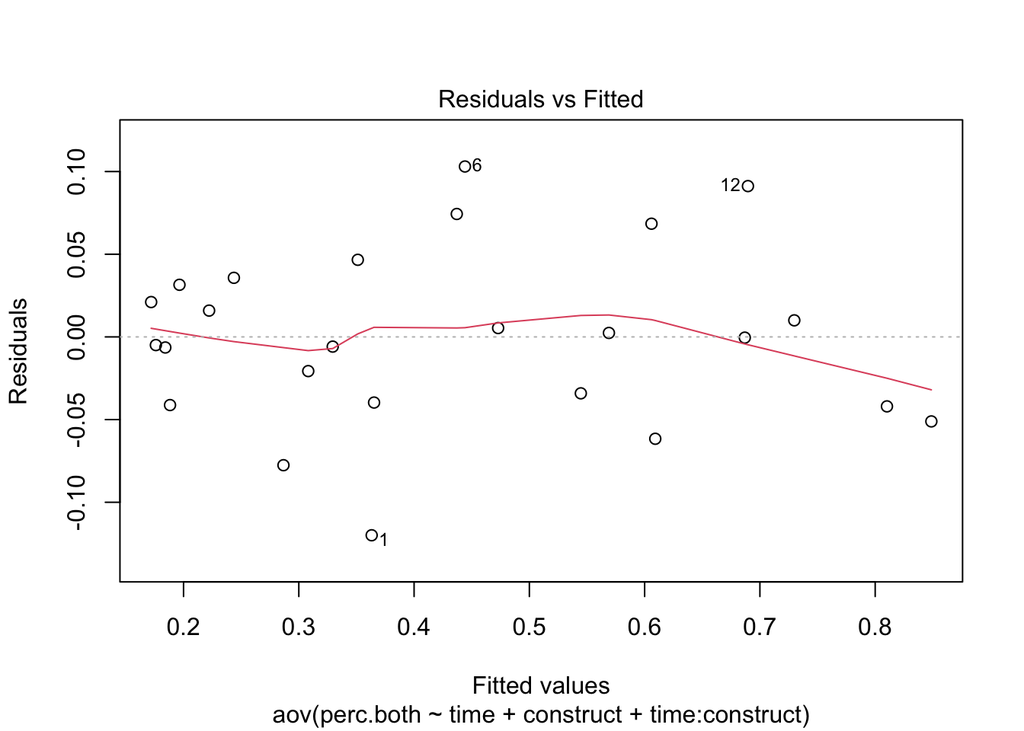

```r
# variance check
plot(aov2, 1)
```

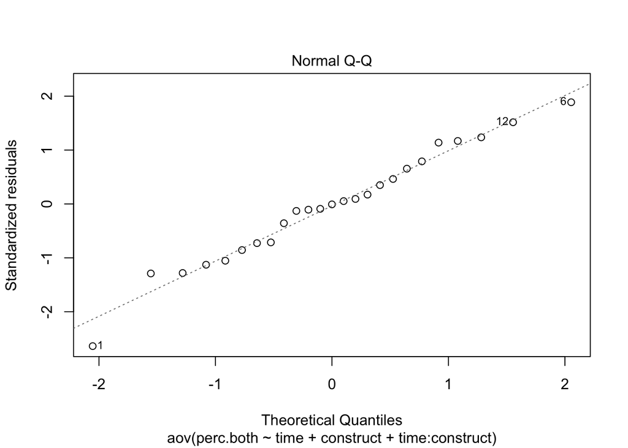

```r
# normality check
plot(aov2, 2)
```

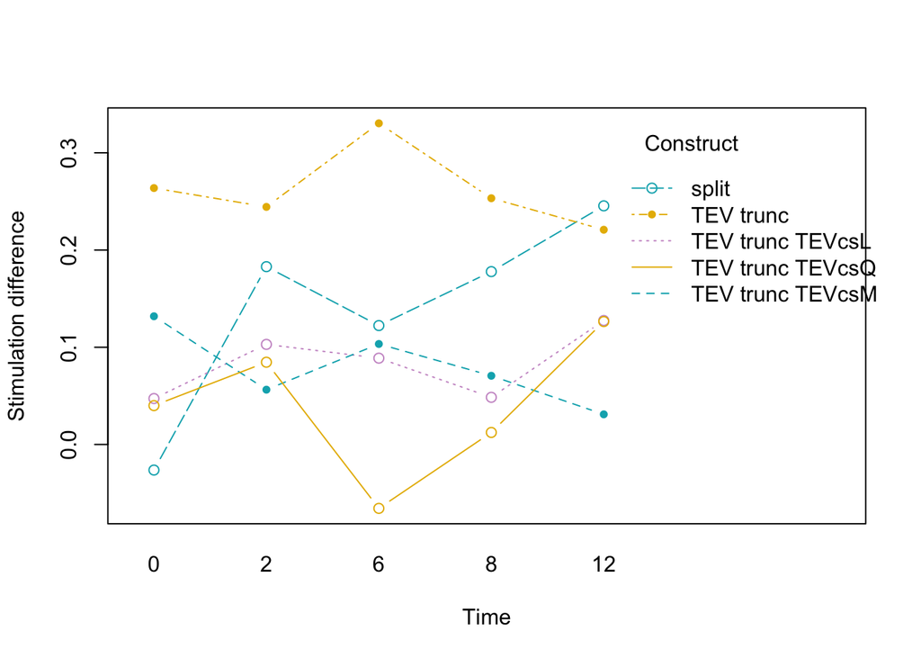

```r
# plot the stimulation difference over time with respect to each construct
interaction.plot(x.factor = difstim$time, trace.factor = difstim$construct,
                 response = difstim$delta, fun = mean,
                 xlab = "Time", ylab="Stimulation difference",
                 type = "b", legend = TRUE,
                 labs(fill='Construct'),
                 pch=c(1,20), col = c("#00AFBB", "#E7B800","#CC99CC"))
```

```r
# two-way anova on the interaction effects of constructs/time on stimulation difference
aov3 <- aov( delta~ time + construct + time:construct, data = difstim)
summary(aov3)
```

```
##                Df  Sum Sq Mean Sq F value   Pr(>F)
## time            1 0.00440 0.00440   1.317 0.269096
## construct       4 0.15138 0.03785  11.319 0.000196 ***
## time:construct  4 0.02710 0.00678   2.026 0.142209
## Residuals      15 0.05016 0.00334
## ---
## Signif. codes:  0 '***' 0.001 '**' 0.01 '*' 0.05 '.' 0.1 ' ' 1
```

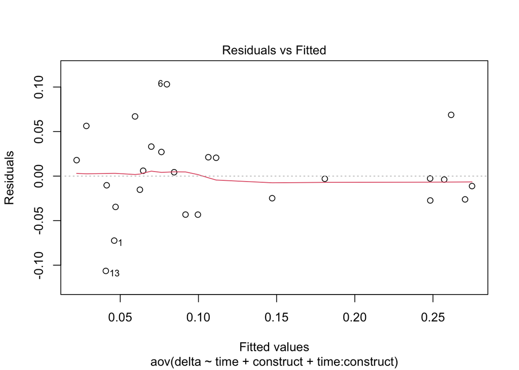

```r
# variance check
plot(aov3, 1)
```

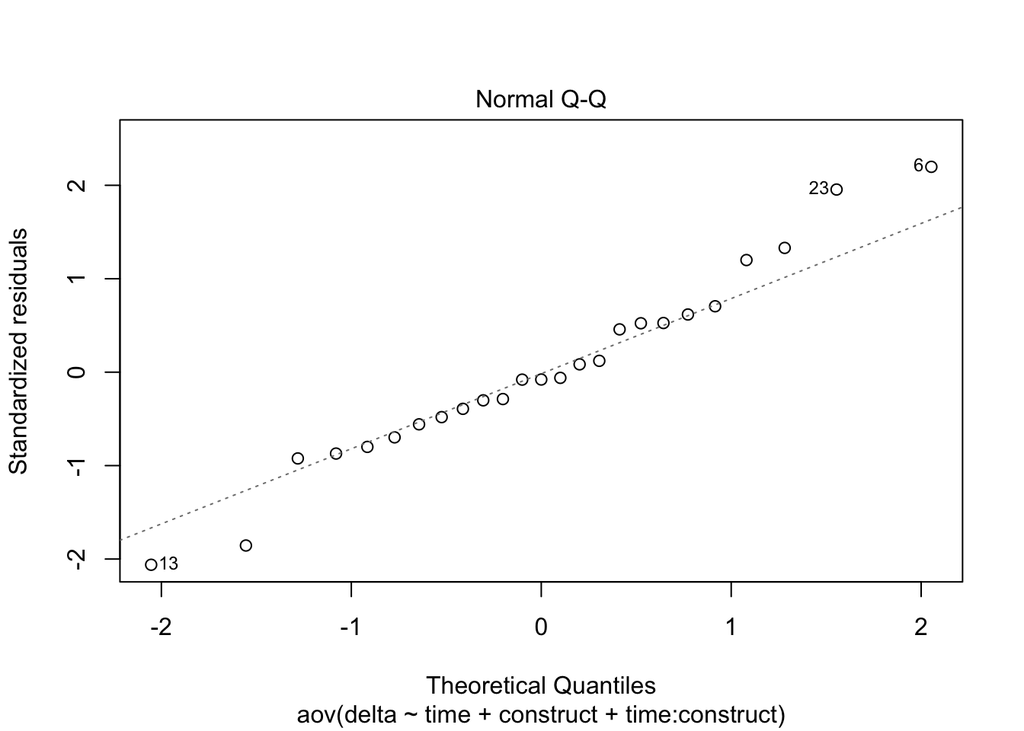

```r
# normality check
plot(aov3, 2)
```

### Conclusion

Based on the raw time point data analysis, there is an drop in mcherry expression in most groups after the FITC exposure. Also there is a trend for the cell death to go up over time in both stimulated/unstimulated groups. Looking closer at the difference between stimulated and unstimulated expression level, the data was first processed by calculating the percentage expression of the mcherry only, FITC only and the mcherry+FITC groups. A paired t-test was ran to compare if the mcherry only and the stimulated group was significantly different. The p-value returned to be 2.475e-06 which supports that the two expression levels were different. The basal, stimulated and differential expression data were also plotted and compared. The interaction effect of the constructs and time was analyzed in all three sets (basal/stimulated/difference). The construct variable appeared to be significant in all three analyses. Time and the interaction between time and construct seemed to significantly contribute in the basal expression and stimulated expression but not in the expression difference. The homoscedasticity was also checked and all three analyses showed moderate variance and closely fitted normality. Although the data didn’t show elevated death rate in the stimulated cells over time, the data did support that there is efficiency differences in the constructs tested.

### References

Chung HK, Zou X, Bajar BT, Brand VR, Huo Y, Alcudia JF, Ferrell JE Jr, Lin MZ. A compact synthetic pathway rewires cancer signaling to therapeutic effector release. Science. 2019 May 3 Tulpule A, Guan J, Neel DS, Allegakoen HR, Lin YP, Brown D, Chou YT, Heslin A, Chatterjee N, Perati S, Menon S, Nguyen TA, Debnath J, Ramirez AD, Shi X, Yang B, Feng S, Makhija S, Huang B, Bivona TG. Kinase-mediated RAS signaling via membraneless cytoplasmic protein granules. Cell. 2021 May 13 Sanchez MI, Ting AY. Directed evolution improves the catalytic efficiency of TEV protease. Nat Methods. 2020 Feb;17(2) —————